# Water Quality in Central Valley

Yueyang Tang & Hyeyoon Cho

2026-05-10

### Import SAFER data

```r
#Importing safer data
safer <- read.csv("SAFER_RA.csv")
```

## Hyeyoon’s part about k-12 schools

Then I wanted to find out how the systems are classified, so I put this code.

### Water System Classifications

```r
unique(safer$FEDERAL_CLASSIFICATION_TYPE)
```

```
## [1] "COMMUNITY"                   "NON-TRANSIENT NON-COMMUNITY"
## [3] "TRANSIENT NON-COMMUNITY"
```

The result it gave me – meaning there are 3 categories of public water systems.

And I wanted to find out how K-12 schools are classified according to these 3 categories, so I entered the code below.

The result was given below. I was able to find out K-12 schools are predominantly categorized as non-transient non-community.

### Filtering K-12 Schools

```r
schools <- safer %>%
  filter(grepl("SCHOOL", SYSTEM_NAME, ignore.case = TRUE))

schools %>%
  count(FEDERAL_CLASSIFICATION_TYPE)
```

```
##   FEDERAL_CLASSIFICATION_TYPE   n
## 1                   COMMUNITY   3
## 2 NON-TRANSIENT NON-COMMUNITY 333
## 3     TRANSIENT NON-COMMUNITY   4
```

And I wanted to find out how many water systems are categorized as non-transient non-community as a whole.

### Identifying At-Risk Schools

```r
safer %>%
  filter(FEDERAL_CLASSIFICATION_TYPE == "NON-TRANSIENT NON-COMMUNITY") %>%
  nrow()
```

```
## [1] 379
```

```r
schools_ntnc <- safer %>%
  filter(FEDERAL_CLASSIFICATION_TYPE == "NON-TRANSIENT NON-COMMUNITY")
```

So there are 333 K-12 schools, out of 379 non-transient non-community public water systems.

Since most non-transient non-community systems are K-12 schools, I wanted to find out which schools have the worst water quality. I used the “at risk” indicator.

```r
schools_ntnc_atrisk <- schools_ntnc %>%
  filter(RISK_ASSESSMENT_RESULT == "At-Risk")
```

And I wanted to see this in a bar graph, by counties.

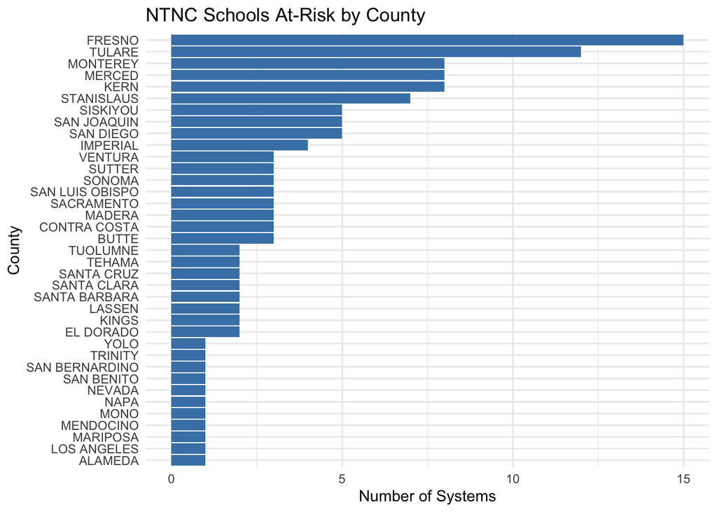

```r
schools_ntnc_atrisk %>%
  count(COUNTY) %>%
  ggplot(aes(x = reorder(COUNTY, n), y = n)) +
  geom_bar(stat = "identity", fill = "steelblue") +
  coord_flip() +
  labs(title = "NTNC Schools At-Risk by County",
       x = "County",
       y = "Number of Systems") +
  theme_minimal()
```

### Correlation Analysis: Failing Schools Correlation between water quality of already failing schools and median household income, affordability, and operational capacity of a water system

```r
schools_ntnc_failing <- schools_ntnc %>%
  filter(FINAL_SAFER_STATUS == "Failing")


schools_ntnc_failing %>%
  select(MHI, WATER_QUALITY_SCORE, WEIGHTED_WATER_QUALITY_SCORE,
         AFFORDABILITY_SCORE, TMF_CAPACITY_SCORE) %>%
  mutate(across(everything(), as.numeric)) %>%
  cor(use = "pairwise.complete.obs") %>%
  round(2)
```

```
##                                MHI WATER_QUALITY_SCORE
## MHI                           1.00               -0.33
## WATER_QUALITY_SCORE          -0.33                1.00
## WEIGHTED_WATER_QUALITY_SCORE -0.33                1.00
## AFFORDABILITY_SCORE          -0.58               -0.01
## TMF_CAPACITY_SCORE           -0.01               -0.03
##                              WEIGHTED_WATER_QUALITY_SCORE AFFORDABILITY_SCORE
## MHI                                                 -0.33               -0.58
## WATER_QUALITY_SCORE                                  1.00               -0.01
## WEIGHTED_WATER_QUALITY_SCORE                         1.00               -0.01
## AFFORDABILITY_SCORE                                 -0.01                1.00
## TMF_CAPACITY_SCORE                                  -0.03               -0.01
##                              TMF_CAPACITY_SCORE
## MHI                                       -0.01
## WATER_QUALITY_SCORE                       -0.03
## WEIGHTED_WATER_QUALITY_SCORE              -0.03
## AFFORDABILITY_SCORE                       -0.01
## TMF_CAPACITY_SCORE                         1.00
```

### Correlation Analysis: All NTNC Schools

Correlation between water quality of all non-transient non-community schools and median household income, affordability, and operational capacity of a water system

```r
schools_ntnc %>% select(MHI, WATER_QUALITY_SCORE, WEIGHTED_WATER_QUALITY_SCORE, AFFORDABILITY_SCORE, TMF_CAPACITY_SCORE) %>% mutate(across(everything(), as.numeric)) %>% cor(use = "pairwise.complete.obs") %>% round(2)
```

```
##                                MHI WATER_QUALITY_SCORE
## MHI                           1.00               -0.04
## WATER_QUALITY_SCORE          -0.04                1.00
## WEIGHTED_WATER_QUALITY_SCORE -0.04                1.00
## AFFORDABILITY_SCORE          -0.45                0.07
## TMF_CAPACITY_SCORE            0.02                0.05
##                              WEIGHTED_WATER_QUALITY_SCORE AFFORDABILITY_SCORE
## MHI                                                 -0.04               -0.45
## WATER_QUALITY_SCORE                                  1.00                0.07
## WEIGHTED_WATER_QUALITY_SCORE                         1.00                0.07
## AFFORDABILITY_SCORE                                  0.07                1.00
## TMF_CAPACITY_SCORE                                   0.05               -0.03
##                              TMF_CAPACITY_SCORE
## MHI                                        0.02
## WATER_QUALITY_SCORE                        0.05
## WEIGHTED_WATER_QUALITY_SCORE               0.05
## AFFORDABILITY_SCORE                       -0.03
## TMF_CAPACITY_SCORE                         1.00
```

#### Findings

But once a school is already failing, the poorer communities tend to have it worse within that failing group. Richer schools aren’t necessarily avoiding failure, but when they do fail they’re not as far down.

## Hyeyoon’s part about Failing Systems Across All Categories

Separately, I wanted to see, out of the 3 categories, which one has the most failing water system.

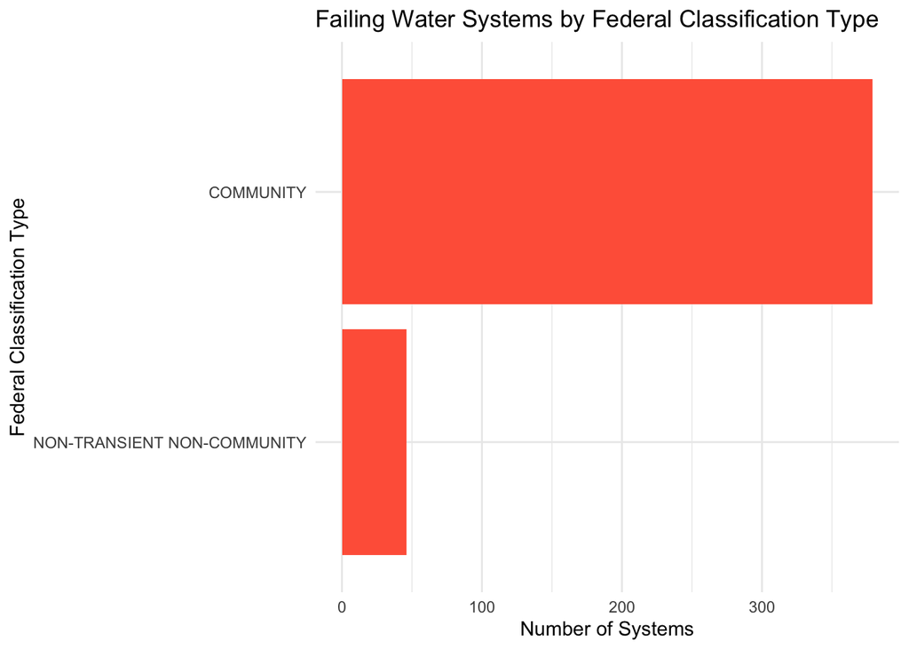

```r
safer %>%
  filter(FINAL_SAFER_STATUS == "Failing") %>%
  count(FEDERAL_CLASSIFICATION_TYPE) %>%
  ggplot(aes(x = reorder(FEDERAL_CLASSIFICATION_TYPE, n), y = n)) +
  geom_bar(stat = "identity", fill = "tomato") +
  coord_flip() +
  labs(title = "Failing Water Systems by Federal Classification Type",
       x = "Federal Classification Type",
       y = "Number of Systems") +
  theme_minimal()
```

```r
#It was the community system. So this is when I thought we should pivot to the community system and analyze them, since they have far more numbers of failing water systems.
```

## Yaelle’s part

### Data Overview

Before anything else, I want to know what fields are available andwhat the key categorical variables look like. How many system types are there, what are the possible risk statuses, etc.

```r
names(safer)
```

```
##   [1] "TINWSYS_IS_NUMBER"
##   [2] "WATER_SYSTEM_NUMBER"
##   [3] "SYSTEM_NAME"
##   [4] "REGULATING_AGENCY"
##   [5] "COUNTY"
##   [6] "FEDERAL_CLASSIFICATION_TYPE"
##   [7] "SERVICE_CONNECTIONS"
##   [8] "POPULATION"
##   [9] "OWNER_TYPE"
##  [10] "PL_ADDRESS"
##  [11] "PL_ADDRESS_CITY_NAME"
##  [12] "PL_ADDRESS_STATE_CODE"
##  [13] "PL_ADDRESS_ZIP_CODE"
##  [14] "LATITUDE_MEASURE"
##  [15] "LONGITUDE_MEASURE"
```

[output cut: 125 more lines]

```r
unique(safer$FEDERAL_CLASSIFICATION_TYPE)
```

```
## [1] "COMMUNITY"                   "NON-TRANSIENT NON-COMMUNITY"
## [3] "TRANSIENT NON-COMMUNITY"
```

```r
unique(safer$FINAL_SAFER_STATUS)
```

```
## [1] "Not At-Risk"         "At-Risk"             "Not Assessed"
## [4] "Failing"             "Potentially At-Risk"
```

```r
unique(safer$CURRENT_FAILING)
```

```
## [1] "Not Failing" "Failing"
```

```r
unique(safer$RISK_ASSESSMENT_RESULT)
```

```
## [1] "Not At-Risk"         "At-Risk"             "Not Assessed"
## [4] "Potentially At-Risk"
```

#### Adding Binary Indicator Columns

To make filtering easier later, I added three 0/1 columns, one for each system type.

```r
safer$ntnc <- as.integer(safer$FEDERAL_CLASSIFICATION_TYPE == "NON-TRANSIENT NON-COMMUNITY")
safer$community <- as.integer(safer$FEDERAL_CLASSIFICATION_TYPE == "COMMUNITY")
safer$tnc <- as.integer(safer$FEDERAL_CLASSIFICATION_TYPE == "TRANSIENT NON-COMMUNITY")
```

#### Creating the Analysis Subset: safer_sub

The full dataset has a lot of columns I don’t need. I pulled out just the ones relevant to this analysis to keep things cleaner.

```r
safer_sub <- safer[, c("TINWSYS_IS_NUMBER", "WATER_SYSTEM_NUMBER", "SYSTEM_NAME",
                       "REGULATING_AGENCY", "COUNTY", "FEDERAL_CLASSIFICATION_TYPE",
                       "SERVICE_CONNECTIONS", "POPULATION", "OWNER_TYPE",
                       "PL_ADDRESS", "PL_ADDRESS_CITY_NAME",
                       "LATITUDE_MEASURE", "LONGITUDE_MEASURE",
                       "SERVICE_AREA_ECONOMIC_STATUS", "MHI", "CALENVIRO_SCREEN_SCORE",
                       "RISK_ASSESSMENT_RESULT", "CURRENT_FAILING",
                       "WATER_QUALITY_SCORE", "WATER_QUALITY_PERCENTAGE_OF_TOTAL_RISK_SCORE",
                       "WATER_QUALITY_RISK_LEVEL",
                       "ntnc", "community", "tnc")]
```

### Which Type of Water System Is Failing the Most?

Now that I know the data structure, the first question is: are all three system types equally at risk, or is one type driving most of the failures?

#### Failure Rates by Water System Type

I looked at raw counts first, then row proportions to compare failure rates across types.

```r
#raw counts, how many systems of each type are failing vs. not
current_fail <- table(safer$FEDERAL_CLASSIFICATION_TYPE, safer$CURRENT_FAILING)
current_fail
```

```
##
##                               Failing Not Failing
##   COMMUNITY                       379        2434
##   NON-TRANSIENT NON-COMMUNITY      46         333
##   TRANSIENT NON-COMMUNITY           0          12
```

```r
prop.table(current_fail, margin = 1)
```

```
##
##                                 Failing Not Failing
##   COMMUNITY                   0.1347316   0.8652684
##   NON-TRANSIENT NON-COMMUNITY 0.1213720   0.8786280
##   TRANSIENT NON-COMMUNITY     0.0000000   1.0000000
```

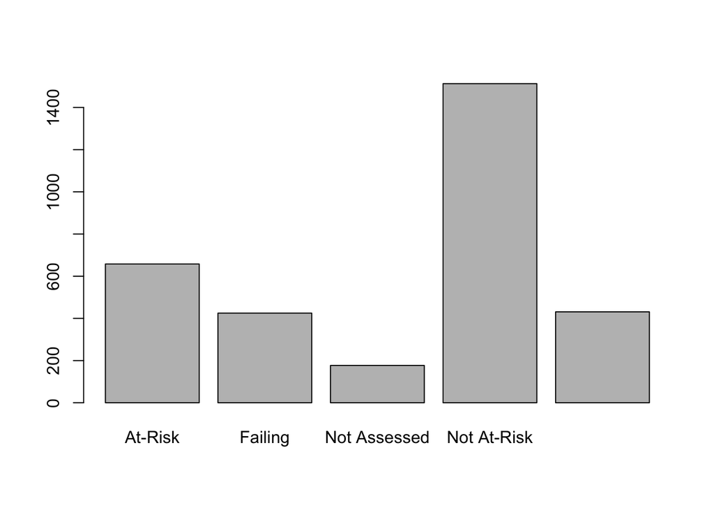

```r
# Convert the counts into row percentages, compare failure RATES across system types
final_status <- table(safer$FINAL_SAFER_STATUS)
barplot(final_status)
```

Community systems make up the vast majority of the dataset (2,813 total vs. 379 NTNC and just 12 TNC). Of all currently failing systems, 379 out of 425 (about 89%) are community systems. That matters because community systems serve people where they live. Only 12 TNC systems appear in the data, which is a very small sample.

#### SAFER Status × System Type: Cross-Tab and Stacked Bar Chart

But raw counts can be misleading if one type just has more systems. So I built a cross-tab to check whether the composition stays the same across risk levels.

```r
#I am trying to answer are Failing or At-Risk systems disproportionately one type, or does the breakdown stay roughly the same across risk levels?
counts <- table(safer$FINAL_SAFER_STATUS, safer$FEDERAL_CLASSIFICATION_TYPE)
props  <- round(prop.table(counts, margin = 1), 2)

combined <- matrix(paste0(counts, " (", props, ")"),
                   nrow = nrow(counts),
                   dimnames = dimnames(counts))
combined <- cbind(combined, Total = rowSums(counts))
combined
```

```
##                     COMMUNITY     NON-TRANSIENT NON-COMMUNITY
## At-Risk             "571 (0.87)"  "87 (0.13)"
## Failing             "379 (0.89)"  "46 (0.11)"
## Not Assessed        "143 (0.81)"  "22 (0.12)"
## Not At-Risk         "1331 (0.88)" "182 (0.12)"
## Potentially At-Risk "389 (0.9)"   "42 (0.1)"
##                     TRANSIENT NON-COMMUNITY Total
## At-Risk             "0 (0)"                 "658"
## Failing             "0 (0)"                 "425"
## Not Assessed        "12 (0.07)"             "177"
## Not At-Risk         "0 (0)"                 "1513"
## Potentially At-Risk "0 (0)"                 "431"
```

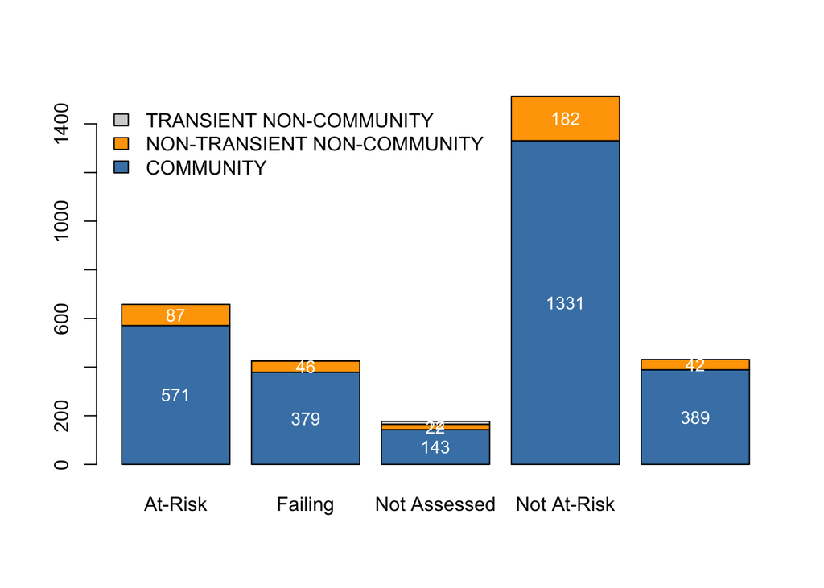

```r
counts <- table(safer$FEDERAL_CLASSIFICATION_TYPE, safer$FINAL_SAFER_STATUS)

bp <- barplot(counts,
              col = c("steelblue", "orange", "lightgray"),
              legend = TRUE,
              args.legend = list(x = "topleft", bty = "n"))

# add labels to the bars
for (i in seq_len(ncol(counts))) {
  ypos <- cumsum(counts[, i]) - counts[, i] / 2
  labels <- ifelse(counts[, i] > 0, counts[, i], "")
  text(bp[i], ypos, labels, col = "white", cex = 0.9)
}
```

TNC systems only show up in the “Not Assessed” row. Maybe they aren’t being evaluated in the SAFER framework.

### Who Is Running the Failing Systems?

1. Who runs these community systems (private, public, etc.)?

```r
# count owner types among community systems only
community <- table(safer$OWNER_TYPE[safer$FEDERAL_CLASSIFICATION_TYPE == "COMMUNITY"])
community
```

```
##
##     FEDERAL GOVERNMENT                  LOCAL MIXED (PUBLIC/PRIVATE)
##                     35                   1004                      2
##                PRIVATE       STATE GOVERNMENT
##                   1725                     47
```

```r
prop_community <- round(prop.table(community), 2)
prop_community
```

```
##
##     FEDERAL GOVERNMENT                  LOCAL MIXED (PUBLIC/PRIVATE)
##                   0.01                   0.36                   0.00
##                PRIVATE       STATE GOVERNMENT
##                   0.61                   0.02
```

61% of community water systems in California are privately owned, with local government second at 36%. So I wanted to see whether private systems also fail at a disproportionate rate.

2. Do some owner types fail or hit “At-Risk” status more than others?

```r
# subset to community systems only
comm <- safer[safer$FEDERAL_CLASSIFICATION_TYPE == "COMMUNITY", ]

# cross-tab
tab <- table(comm$OWNER_TYPE, comm$FINAL_SAFER_STATUS)
tab
```

```
##
##                          At-Risk Failing Not Assessed Not At-Risk
##   FEDERAL GOVERNMENT           8       0            0          21
##   LOCAL                      168      96          116         507
##   MIXED (PUBLIC/PRIVATE)       0       0            0           2
##   PRIVATE                    377     282           24         785
##   STATE GOVERNMENT            18       1            3          16
##
##                          Potentially At-Risk
##   FEDERAL GOVERNMENT                       6
##   LOCAL                                  117
##   MIXED (PUBLIC/PRIVATE)                   0
##   PRIVATE                                257
##   STATE GOVERNMENT                         9
```

Of the 379 failing community systems, 282 (74%) are privately owned

### Where Are the Failures Concentrated?

After I know it’s mostly private community systems failing, I wanted to see where geographically. Both by number of failing systems per county, and by how many people are actually affected.

```r
# filter
subset_data <- safer[safer$FEDERAL_CLASSIFICATION_TYPE == "COMMUNITY" &
                     safer$OWNER_TYPE == "PRIVATE" &
                     safer$FINAL_SAFER_STATUS == "Failing", ]

# total population served by these systems
sum(subset_data$POPULATION, na.rm = TRUE)
```

```
## [1] 138211
```

```r
# count by county, sorted high to low
sort_county <- sort(table(subset_data$COUNTY), decreasing = TRUE)
sort_county
```

```
##
##            KERN          SONOMA       SAN DIEGO        MONTEREY  SAN BERNARDINO
##              40              26              21              18              18
##          MADERA     LOS ANGELES          FRESNO          TULARE SAN LUIS OBISPO
##              15              14               9               9               8
##      STANISLAUS         VENTURA     SAN JOAQUIN     SANTA CLARA       RIVERSIDE
##               8               8               7               7               6
##       MENDOCINO   SANTA BARBARA        TUOLUMNE      SAN BENITO       SAN MATEO
##               5               5               5               4               4
##      SANTA CRUZ    CONTRA COSTA        HUMBOLDT        IMPERIAL            INYO
##               4               3               3               3               3
##      SACRAMENTO          AMADOR           BUTTE       DEL NORTE            LAKE
##               3               2               2               2               2
##          SHASTA          SUTTER          TEHAMA         TRINITY            YUBA
##               2               2               2               2               2
##       EL DORADO          LASSEN        MARIPOSA          MERCED            MONO
##               1               1               1               1               1
##            NAPA          NEVADA            YOLO
##               1               1               1
```

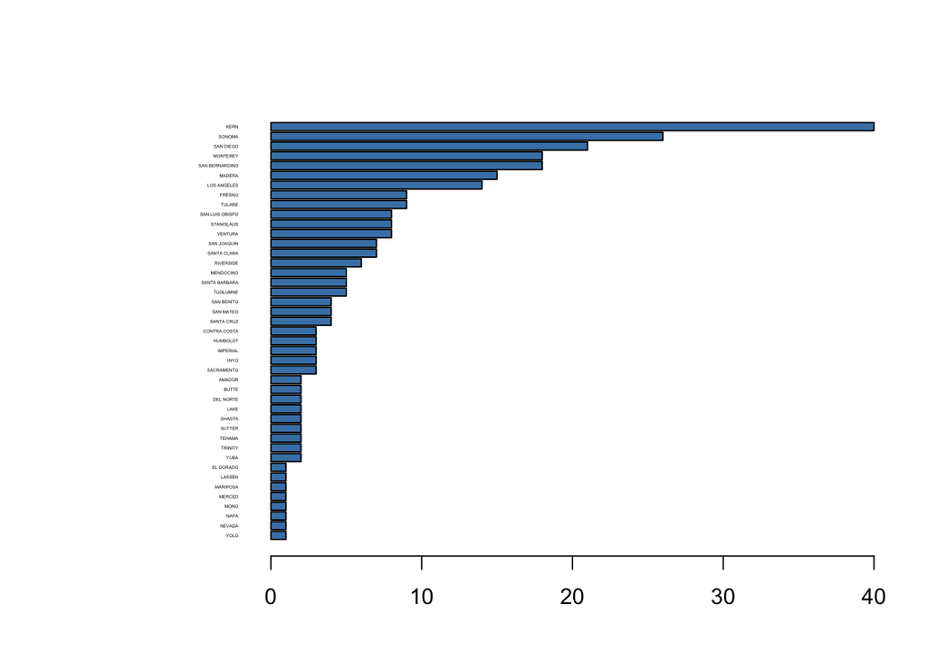

```r
# bar chart: most-failing counties on top
sort_county <- rev(sort_county)

par(mar = c(4, 10, 4, 2))
bp <- barplot(sort_county,
              horiz = TRUE,
              las = 1,
              cex.names = 0.2,
              col = "steelblue")
```

Kern County has by far the most failing private community systems (40), followed by Sonoma (26) and San Diego (21). But system count alone doesn’t tell the full story. A county with fewer systems could still affect far more people. So I also looked at population impact.

#### Counties with the Largest Affected Populations

```r
# all failing or at-risk systems
risk_data <- safer[safer$FINAL_SAFER_STATUS %in% c("Failing", "At-Risk"), ]

# total population served
sum(risk_data$POPULATION, na.rm = TRUE)
```

```
## [1] 2527963
```

```r
# break down by system type and status
aggregate(POPULATION ~ FEDERAL_CLASSIFICATION_TYPE + FINAL_SAFER_STATUS,
          data = risk_data, FUN = sum, na.rm = TRUE)
```

```
##   FEDERAL_CLASSIFICATION_TYPE FINAL_SAFER_STATUS POPULATION
## 1                   COMMUNITY            At-Risk    1941950
## 2 NON-TRANSIENT NON-COMMUNITY            At-Risk      26096
## 3                   COMMUNITY            Failing     543769
## 4 NON-TRANSIENT NON-COMMUNITY            Failing      16148
```

```r
# population by county, failing or at-risk
county_pop <- aggregate(POPULATION ~ COUNTY, data = risk_data,
                        FUN = sum, na.rm = TRUE)
county_pop[order(-county_pop$POPULATION), ]
```

```
##             COUNTY POPULATION
## 19     LOS ANGELES     382287
## 36  SAN BERNARDINO     328986
## 15            KERN     240519
## 10          FRESNO     203912
## 33       RIVERSIDE     145607
## 41   SANTA BARBARA     121355
## 38     SAN JOAQUIN     100822
## 53          TULARE      92873
## 24          MERCED      88365
## 55         VENTURA      87307
## 13        IMPERIAL      87107
## 16           KINGS      82656
## 1          ALAMEDA      76739
## 49      STANISLAUS      74148
```

[output cut: 43 more lines]

```r
# narrowing to failing only
failing_data <- safer[safer$FINAL_SAFER_STATUS == "Failing", ]
county_pop2 <- aggregate(POPULATION ~ COUNTY, data = failing_data,
                        FUN = sum, na.rm = TRUE)
county_pop2[order(-county_pop2$POPULATION), ]
```

```
##             COUNTY POPULATION
## 1          ALAMEDA      76689
## 8           FRESNO      75398
## 12            KERN      55845
## 44          TULARE      45413
## 13           KINGS      42123
## 20          MERCED      41099
## 26       RIVERSIDE      37710
## 16     LOS ANGELES      34540
## 30       SAN DIEGO      34071
## 29  SAN BERNARDINO      30194
## 40      STANISLAUS      11807
## 17          MADERA       8233
## 4           COLUSA       6959
## 23            NAPA       5530
```

[output cut: 34 more lines]

Counties with the most people served by failing systems are not necessarily the ones with the most failing systems. Alameda County ranks first in affected population, but when I went back to check, there is actually only one failing water system there. It just serves a very large number of people. This is a good reminder that system count and population impact tell different stories.

Fresno and Kern follow, and unlike Alameda, their high numbers reflect a concentration of many smaller failing systems.

So, this lead me to think whether system size matters. Maybe smaller water systems will more likely to fail compared to larger ones. If so, what size is most likely to fail.

### System size

```r
# convert to numeric first
safer <- safer %>%
  mutate(WATER_QUALITY_SCORE = as.numeric(WATER_QUALITY_SCORE))
# basic summary
summary(safer$WATER_QUALITY_SCORE)
```

```
##    Min. 1st Qu.  Median    Mean 3rd Qu.    Max.    NA's
##  0.0000  0.0000  0.0800  0.2738  0.5000  2.0000     178
```

```r
sum(safer$WATER_QUALITY_SCORE == 0, na.rm = TRUE)
```

```
## [1] 1380
```

```r
sum(safer$WATER_QUALITY_SCORE > 0, na.rm = TRUE)
```

```
## [1] 1646
```

The dataset contains 3,026 systems with a water quality score. 1,380 of them (46%) score exactly 0, meaning they have no recorded water quality violations at all.

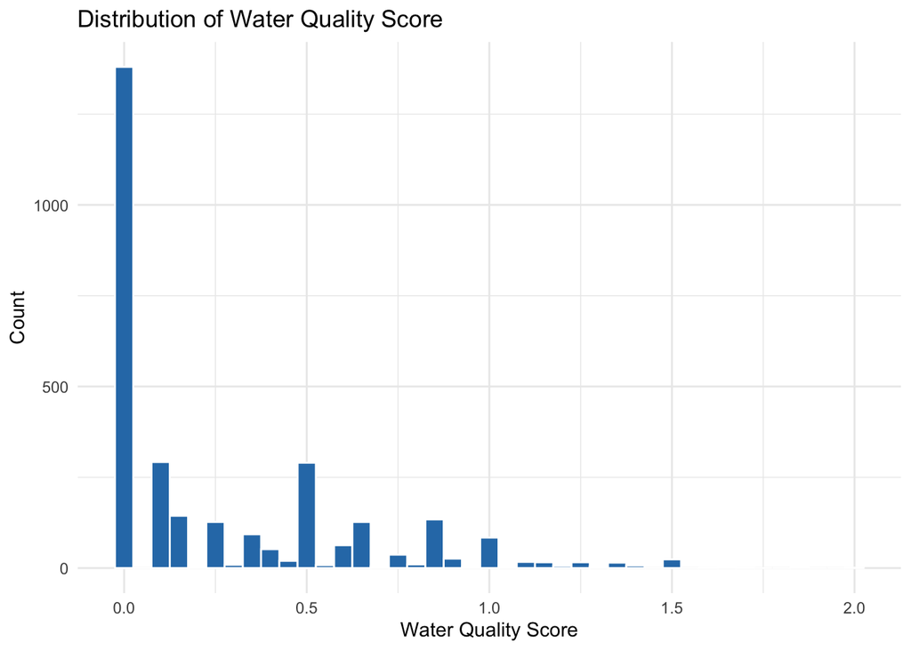

```r
# histogram
ggplot(safer, aes(x = WATER_QUALITY_SCORE)) +
  geom_histogram(binwidth = 0.05, fill = "#2c7bb6", color = "white") +
  labs(
    title = "Distribution of Water Quality Score",
    x = "Water Quality Score",
    y = "Count"
  ) +
  theme_minimal()
```

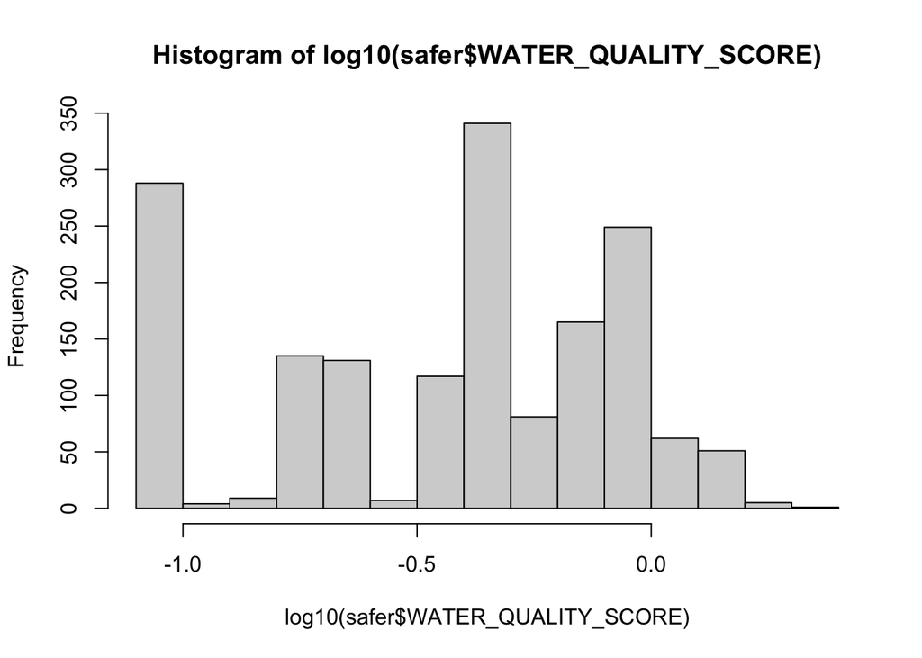

```r
# log-transformed, easier to see the spread
hist(log10(safer$WATER_QUALITY_SCORE))
```

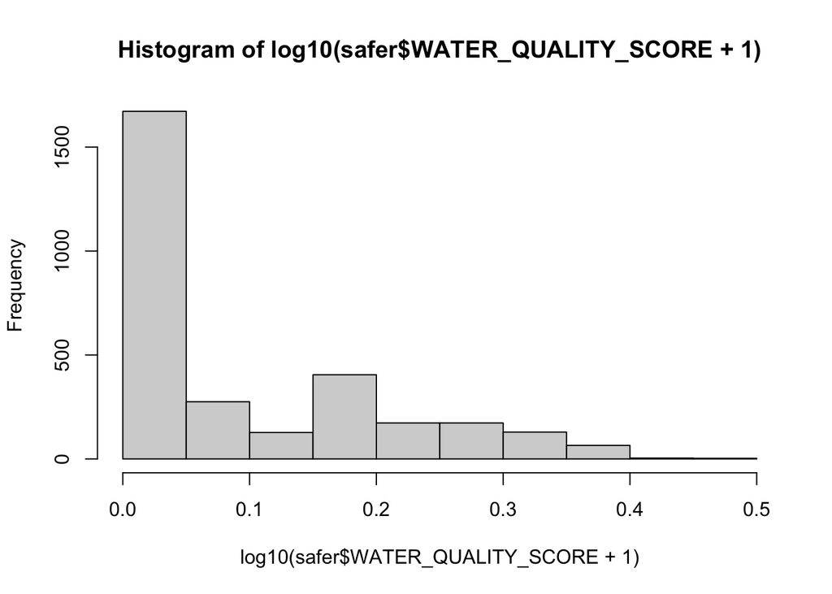

```r
hist(log10(safer$WATER_QUALITY_SCORE+1))
```

there isn’t a smooth spectrum of water quality problems. Systems tend to either have minor issues or significantly worse ones.

#### System Size Distribution

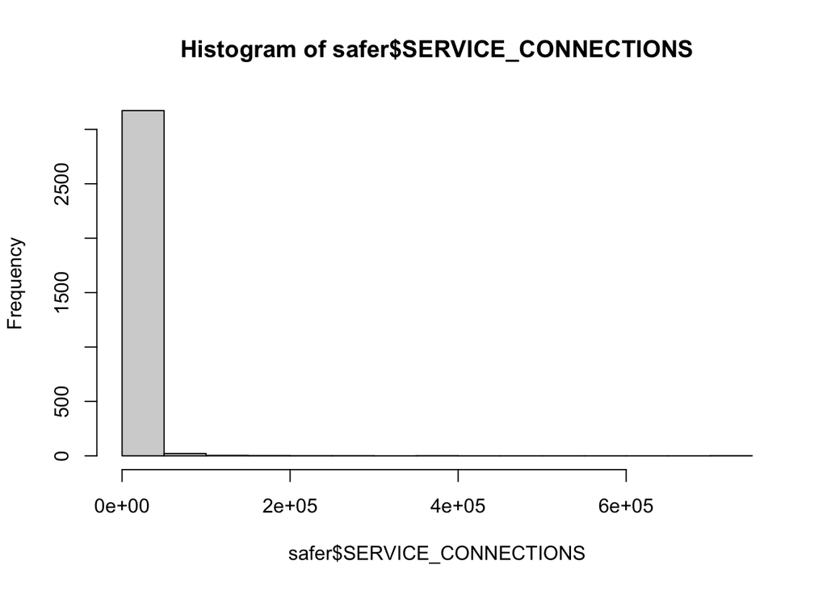

```r
hist(safer$SERVICE_CONNECTIONS)
```

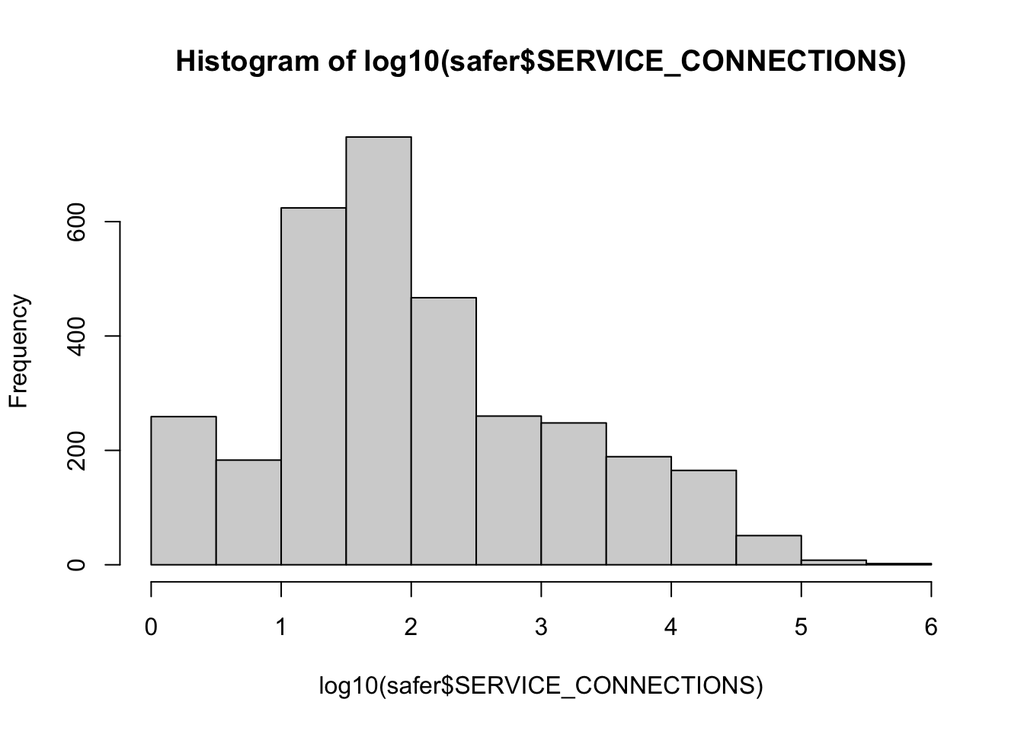

```r
hist(log10(safer$SERVICE_CONNECTIONS))
```

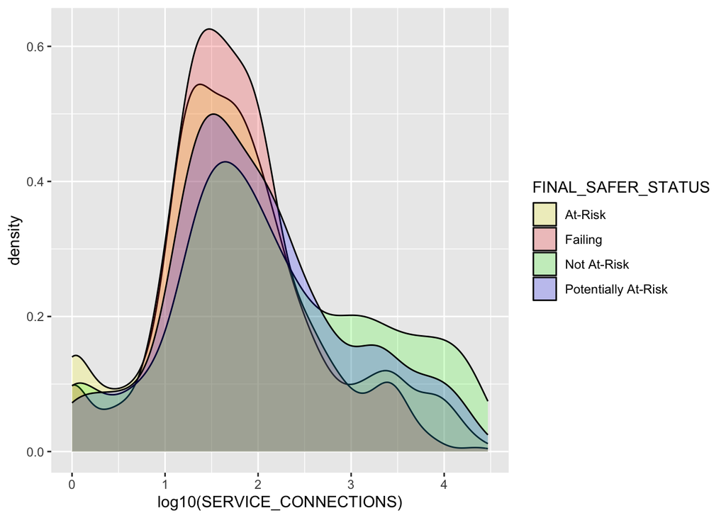

```r
safer %>%
  filter(FINAL_SAFER_STATUS %in% c("Failing", "At-Risk", "Potentially At-Risk", "Not At-Risk")) %>%
  ggplot(aes(x = log10(SERVICE_CONNECTIONS), fill = FINAL_SAFER_STATUS)) +
  geom_density(alpha = 0.2) +
  scale_fill_manual(values = c(
    "Failing"            = "red",
    "At-Risk"            = "yellow",
    "Potentially At-Risk" = "blue",
    "Not At-Risk"        = "green"
  ))
```

A raw histogram of SERVICE_CONNECTIONS was difficult to read: most systems are very small while a handful are extremely large, so small systems get visually crushed. So I use a log10 transformation fixed this.

The distribution peaked around log10 ≈ 1.5, meaning the most common water system in California serves only about 30 connections. These are very small, often serving a single neighborhood or rural community.

Then I overlaid density curves for all four risk categories. The peak at log10 ≈ 1.5 is tallest for Failing systems and progressively shorter as risk level decreases, meaning small systems are far more likely to be failing.

### Who Bears the Risk most

#### correlation

```r
# change to numeric
safer <- safer %>%
  mutate(
    MHI = as.numeric(MHI),
    SERVICE_CONNECTIONS = as.numeric(SERVICE_CONNECTIONS),
    WATER_QUALITY_SCORE = as.numeric(WATER_QUALITY_SCORE)
  )
# using log10(score + 1) to retain zero-score systems
# correlation
cor(safer$MHI, log10(safer$WATER_QUALITY_SCORE+1), use="pairwise.complete.obs")
```

```
## [1] -0.1093724
```

```r
cor(safer$SERVICE_CONNECTIONS, log10(safer$WATER_QUALITY_SCORE+1), use="pairwise.complete.obs")
```

```
## [1] -0.01915681
```

Both correlations are weak…… So I decided to give up on this angel… No!! I wasn’t ready to drop the income angle entirely.

A low linear correlation doesn’t rule out a distributional pattern. So I looked at SERVICE_AREA_ECONOMIC_STATUS instead, which classifies communities into DAC tiers rather than treating income as a continuous variable.

```r
safer$risk_flag <- ifelse(safer$FINAL_SAFER_STATUS %in% c("Failing", "At-Risk"),
                          "Failing/At-Risk", "Other")

table(safer$SERVICE_AREA_ECONOMIC_STATUS)
```

```
##
##             DAC Missing Non-DAC    SDAC
##      12     938       3    1062    1189
```

```r
sum(safer$SERVICE_AREA_ECONOMIC_STATUS == "")
```

```
## [1] 12
```

```r
#clean the blank data, put into "missing" category
safer$SERVICE_AREA_ECONOMIC_STATUS[safer$SERVICE_AREA_ECONOMIC_STATUS == ""] <- "Missing"
table(safer$SERVICE_AREA_ECONOMIC_STATUS)
```

```
##
##     DAC Missing Non-DAC    SDAC
##     938      15    1062    1189
```

```r
#write csv for visualization in datawrapper
economic_status <- table(safer$risk_flag, safer$SERVICE_AREA_ECONOMIC_STATUS)
write.csv(economic_status, "economic_status.csv")
```

Nearly half (49%) of Failing or At-Risk water systems serve severely disadvantaged communities (SDAC), compared to just 31% among systems that are not struggling. Meanwhile, systems serving wealthier Non-DAC communities make up 39% of the “Other” group but only 21% of Failing/At-Risk systems.

So, the poorer the community, the more likely its water system is in trouble.

#### MHI Comparison

Communities served by Failing or At-Risk systems have an average household income of $62,426, nearly $14,640 less than the $77,066 average for systems that are doing fine.

I ran a t-test to confirm this gap is statistically significant. The p-value is essentially zero, meaning the difference is almost certainly not due to chance.

```r
safer$MHI <- as.numeric(safer$MHI)

aggregate(MHI ~ risk_flag, data = safer,
          FUN = function(x) c(mean   = mean(x,   na.rm = TRUE),
                              median = median(x,  na.rm = TRUE),
                              n      = sum(!is.na(x))))
```

```
##         risk_flag MHI.mean MHI.median    MHI.n
## 1 Failing/At-Risk 62425.69   58710.50  1078.00
## 2           Other 77065.84   70910.00  2111.00
```

```r
t.test(MHI ~ risk_flag, data = safer)
```

```
##
##  Welch Two Sample t-test
##
## data:  MHI by risk_flag
## t = -12.022, df = 2516.1, p-value < 2.2e-16
## alternative hypothesis: true difference in means between group Failing/At-Risk and group Other is not equal to 0
## 95 percent confidence interval:
##  -17028.14 -12252.15
## sample estimates:
## mean in group Failing/At-Risk           mean in group Other
##                      62425.69                      77065.84
```

```r
central_valley <- safer %>%
  filter(COUNTY %in% c("KERN", "FRESNO", "MERCED", "TULARE", "MADERA"))

t.test(MHI ~ risk_flag, data = central_valley)
```

```
##
##  Welch Two Sample t-test
##
## data:  MHI by risk_flag
## t = -4.2331, df = 501.71, p-value = 2.742e-05
## alternative hypothesis: true difference in means between group Failing/At-Risk and group Other is not equal to 0
## 95 percent confidence interval:
##  -11749.24  -4300.19
## sample estimates:
## mean in group Failing/At-Risk           mean in group Other
##                      52390.77                      60415.49
```

```r
aggregate(MHI ~ risk_flag, data = central_valley,
          FUN = function(x) c(mean   = mean(x,   na.rm = TRUE),
                              median = median(x,  na.rm = TRUE),
                              n      = sum(!is.na(x))))
```

```
##         risk_flag MHI.mean MHI.median    MHI.n
## 1 Failing/At-Risk 52390.77   52299.00   313.00
## 2           Other 60415.49   59118.00   236.00
```

### What chemical drives most failing water systems?

We know that poorer communities are more exposed to failing water systems. The next question is: what chemical drives most failing water systems?

I started with the full statewide picture, then drilled down by county.

```r
fail_all <- safer[safer$FINAL_SAFER_STATUS == "Failing" &
                    safer$PRIMARY_MCL_VIOLATION == "YES",]

analytes_all <- unlist(strsplit(fail_all$PRIMARY_ANALYTES, ";\\s*"))
analytes_all <- trimws(analytes_all)
violation_all <- sort(table(analytes_all), decreasing = TRUE)
violation_all
```

```
## analytes_all
##                       NITRATE                       ARSENIC
##                            86                            76
##        1,2,3-TRICHLOROPROPANE              COMBINED URANIUM
##                            65                            32
## TOTAL HALOACETIC ACIDS (HAA5)                          TTHM
##                            25                            23
##                      FLUORIDE GROSS ALPHA PARTICLE ACTIVITY
##                            14                             8
##               NITRATE-NITRITE                      SELENIUM
##                             6                             6
##                   PERCHLORATE   1,2-DIBROMO-3-CHLOROPROPANE
##                             3                             2
##          1,1-DICHLOROETHYLENE           ALUMINUM, DISSOLVED
##                             1                             1
##               ANTIMONY, TOTAL                 CHROMIUM, HEX
##                             1                             1
```

```r
length(unique(analytes_all))
```

```
## [1] 16
```

```r
#write csv for visualization in datawrapper
write.csv(violation_all, "violation_all.csv")
```

Among California’s Failing water systems with a Primary MCL violation, Nitrate, Arsenic, and TCP are the contaminants most frequently exceeding safe drinking water standard

```r
county_analytes_long <- safer %>%
  filter(FINAL_SAFER_STATUS == "Failing" & PRIMARY_MCL_VIOLATION == "YES") %>%
  select(COUNTY, PRIMARY_ANALYTES) %>%
  mutate(analyte = strsplit(PRIMARY_ANALYTES, ";\\s*")) %>%
  unnest(analyte) %>%
  mutate(analyte = trimws(analyte)) %>%
  count(COUNTY, analyte, name = "frequent") %>%
  arrange(COUNTY, desc(frequent))

write_csv(county_analytes_long, "county_analytes_long.csv")
```

Two patterns I want to mention:

First, 1,2,3-Trichloropropane (known as TCP) is heavily concentrated in Central Valley counties, particularly Kern, Fresno, Merced, and Tulare. TCP is a byproduct of pesticides that were banned decades ago, but because it binds to groundwater and breaks down extremely slowly, it continues to contaminate drinking water sources today.

Second, nitrate violations cluster in the same region, driven by decades of intensive agricultural fertilizer use and livestock waste that leach into groundwater.